# Filtering rows

# 1 Data wrangling: filtering rows

## 1.1 Learning objectives

1. You will use `dplyr::filter()` to keep or drop rows from a dataframe.
2. You will filter rows by specifying conditions on numbers or strings using relational operators like greater than (`>`), less than (`<`), equal to (`==`), and not equal to (`!=`).
3. You will filter rows by combining conditions using logical operators like the ampersand (`&`) and the vertical bar (`|`).
4. You will filter rows by negating conditions using the exclamation mark (`!`) logical operator.
5. You will filter rows with missing values using the `is.na()` function.

## 1.2 The Yaounde COVID-19 dataset

We continue to use the data from the COVID-19 serological survey from Yaounde.

```r
yaounde <- read_csv(here::here('data/yaounde_data.csv'))
## a smaller subset of variables
yao <- yaounde %>%
  select(age, sex, weight_kg, highest_education, neighborhood,
         occupation, is_smoker, is_pregnant,
         igg_result, igm_result)
yao
```

```
## # A tibble: 971 × 10
##      age sex    weight_kg highest_education neighborhood occupation    is_smoker
##    <dbl> <chr>      <dbl> <chr>             <chr>        <chr>         <chr>
##  1    45 Female        95 Secondary         Briqueterie  Informal wor… Non-smok…
##  2    55 Male          96 University        Briqueterie  Salaried wor… Ex-smoker
##  3    23 Male          74 University        Briqueterie  Student       Smoker
##  4    20 Female        70 Secondary         Briqueterie  Student       Non-smok…
##  5    55 Female        67 Primary           Briqueterie  Trader--Farm… Non-smok…
##  6    17 Female        65 Secondary         Briqueterie  Student       Non-smok…
##  7    13 Female        65 Secondary         Briqueterie  Student       Non-smok…
##  8    28 Male          62 Doctorate         Briqueterie  Student       Non-smok…
##  9    30 Male          73 Secondary         Briqueterie  Trader        Non-smok…
## 10    13 Female        56 Secondary         Briqueterie  Other         Non-smok…
## # ℹ 961 more rows
## # ℹ 3 more variables: is_pregnant <chr>, igg_result <chr>, igm_result <chr>
```

## 1.3 Introducing `filter()`

We use `filter()` to keep rows that satisfy a set of conditions.

Let’s take a look at a simple example.

If we want to keep just the male records, we run:

```r
yao ____________________ # Filter for sex equal to "Male"
```

[output not shown]

Note the use of the double equal sign `==` rather than the single equal sign `=`.

We can chain `filter()` with `nrow()` to get the number of rows fulfilling a condition.

```r
## how many respondents were male?
yao %>%
  _______________________ %>%
  _________________
```

[output not shown]

The double equal sign, `==`, tests for equality,

while the single equals sign, `=`, is used for specifying values to arguments inside functions.

Filter the `yao` data frame to respondents who were pregnant during the survey.

How many respondents were female? (Use `filter()` and `nrow()`)

## 1.4 Relational operators

The `==` operator introduced above is an example of a “relational” operator

Here is a list of some of these operators.

| **Operator** | **is TRUE if** |
| --- | --- |
| A < B | A is **less than** B |
| A <= B | A is **less than or equal** to B |
| A > B | A is **greater than** B |
| A >= B | A is **greater than or equal to** B |
| A == B | A is **equal** to B |
| A != B | A is **not equal** to B |
| A %in% B | A **is an element of** B |

Take your time to pause the video and look over them.

You can also save the resource to come back to it when you code.

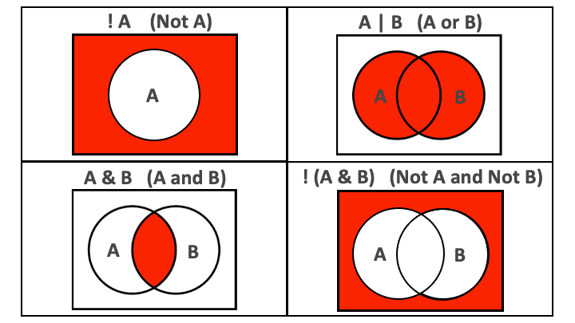

Fig: AND and OR operators visualized.

Let’s see how to use these within `filter()`:

```r
yao %>% filter(____________) ## keep rows where `sex` is not "Male"
yao %>% filter(____________) ## keep respondents under 6
yao %>% filter(____________) ## keep respondents aged at least 70

## keep respondents whose highest education is "Primary" or "Secondary"
yao %>% filter(___________________________________)
```

[output not shown]

From `yao`, keep only respondents who were children (under 18).

With `%in%`, keep only respondents who live in the “Tsinga” or “Messa” neighborhoods.

## 1.5 Combining conditions with `&` and `|`

A single `filter()` statement can encompass multiple conditions.

The conditions are separated by commas:

```r
## keep respondents who are pregnant and are ex-smokers
yao %>% filter(_____________________________________) ## only one row
```

[output not shown]

When multiple conditions are separated by a comma, they are implicitly combined with an **and** (`&`).

Good practice is to replace the comma with `&` to make this more explicit.

```r
## same result as before, but `&` is more explicit
yao %>% filter(_____________________________________)
```

[output not shown]

Don’t confuse:

- the “,” in listing several conditions in filter `filter(A,B)` i.e. filter based on condition A and (`&`) condition B
- the “,” in lists `c(A,B)` which is listing different components of the list (and has nothing to do with the `&` operator)

If we want to combine conditions with an **or**, we use the vertical bar symbol, `|`.

```r
## respondents who are pregnant OR who are ex-smokers
yao %>% filter(___________________________________________)
```

[output not shown]

Filter `yao` to only keep men who tested IgG positive.

Filter `yao` to keep both children (under 18) and anyone whose highest education is primary school.